Travel Website - Iberostar

==========================================

**Bhuvnesh Singh and Varun Gupta** - *INSEAD MBA 16J*

bhuvnesh.singh@insead.edu varun.gupta@insead.edu

## Business motivation

Our client Iberostar Hotels & Resorts is a hotel chain based in Spain, specializing in 4 and 5 star hotels. It is owned by Grupo Iberostar, which also owns Iberostate Golf, Villas & Condos, Iberoservice its incoming tourism division and Iberostar The Club.

The client has its own website and receives traffic from several countries. In this case, we have looked into the traffic data of the client and have tried to look for bottled down factors that drive the booking and hence the revenue for the client. Further, we have looked at the possible clusters in the traffic data.

## Data Description

Let’s review the contents of the data

- **Type of User**: Returning or New Visitor
- **Source**: Organic vs Paid Promotions
- **Users**: Number of User Visits
- **Sessions**: Number of User Sessions
- **No of Pages Visited**: Number of total pages visited
- **No of Transactions**: Number of monetary transactions
- **Revenue**: Revenue generated
- **Dummy Variable**: We created dummy variables categorical data such as ‘user type’, ‘source’ and ‘device type’

However, from a business sense, bucketing these attribute does not make much sense hence we do not recommend dimension reduction in this case.

**Now, let’s look at how Revenue/Transaction and Transactions vary with device type (Desktop, Mobile and Tablet):**

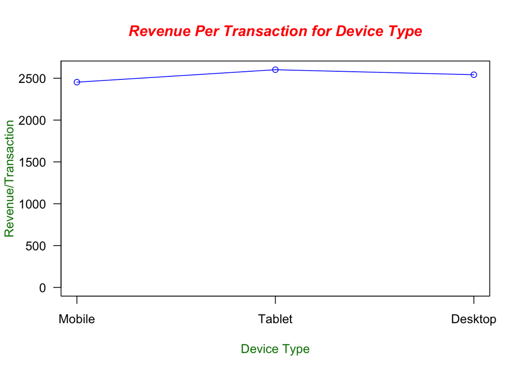

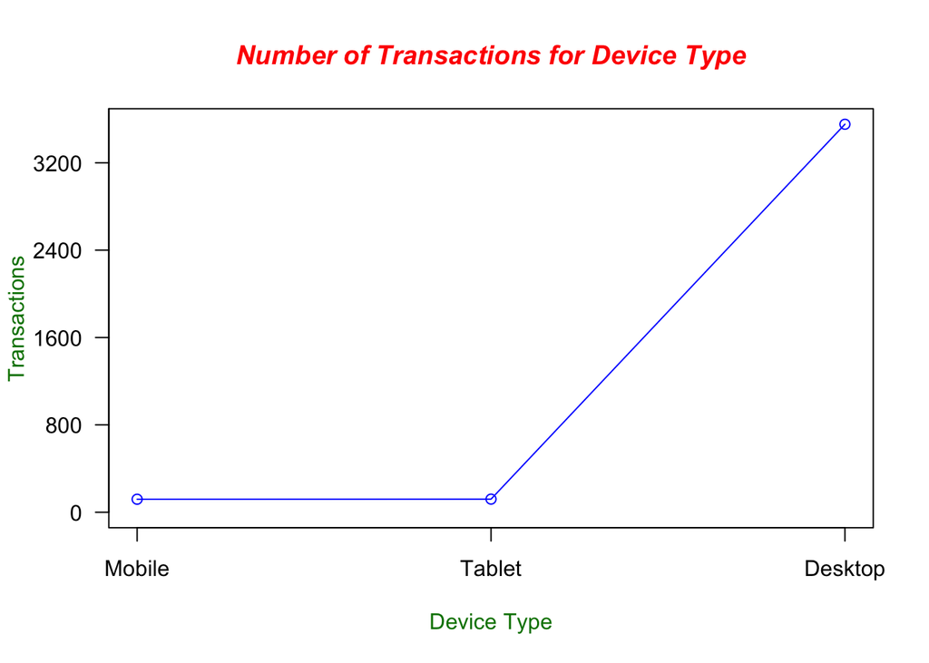

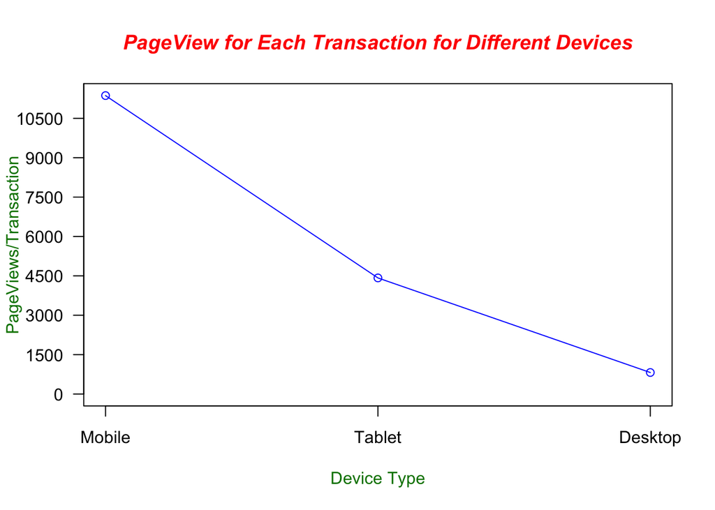